# Lab 3

Author

Giovanni Librizzi

# Revision:

First I incorrectly read through the data sheet and missed the spot where they specified the missing data was replaced with the mean. I should have thoroughly read through the data sheet and made sure to double check any specification on missing values. Next on Q5, I didn’t think about efficiency and just tried to brute force it to get it working. I should have realized there was a much easier way to accomplish this goal– using across inside the mutate. On Q10 graphs, the box plots didn’t demonstrate the extent of the data, just the count. I replaced it with a jitter plot and box plot that display the points of data the plot has. Then on the last question, I should have used a slice_max to get the top bieber fans instead of just finding which ones had the max score.

# Getting Started

Download starter .qmd file

**Add your preferred YAML**

The downloaded file **does not** contain an YAML, you need to include your own. This allows you to specify how you would like your rendered HTML to look! The sky is the limit!

Download `hiphop.csv`

**Warning**

Save **both** your .qmd file and your data set in the same folder within your Stat 331 directory! **DO NOT** open your .qmd file straight from your downloads folder.

## Tips for Formatting your Lab

**Tip**

- The first chunk of your Quarto document should be to *declare your libraries* (probably only `tidyverse` for now).
- The second chunk of your Quarto document should be to *load in your data* (using the `here()` function!).
- Make sure you address **all the questions** in these instructions.
- If a question requires **any** type of calculation, **you should provide code for your answer!**
- I have provided hints about functions that might be useful to you. You are **not required** to use these functions.
- You may have to Google to solve some of these!
- Be sure to **save** your work regularly (`Ctrl/Cmd + S` or `File > Save` or the floppy disk icon)
- Be sure to **render** your file every so often, to check for errors and make sure it looks nice.
  - Make your Quarto document does not contain `View(dataset)` or `install.packages("package")`, both of these will prevent rendering.
  - Check your Quarto document for moments when you looked at the data by typing the name of the data frame. Leaving these in means the whole dataset will print out and this looks unprofessional.
  - If you are unable to finish due to errors in your code, remember that you can still submit an HTML file if you specify `error: true` in your `execute` options (in the YAML).

# Data Set

The data set `hiphop` contains results from a study conducted by a linguist at the University of Minnesota. The researcher was interested in predicting musical taste based on familiarity with African American English (AAE). 168 subjects participated in the study, and each was asked to define 64 different AAE terms. The definitions given were used to create a `familiarity` score for each subject for each term. This score quantifies how well the subject knew the term on a scale of 1-5 (1 = not at all, 5 = very well). Before tackling the problems, study the description of each variable [here](http://conservancy.umn.edu/bitstream/handle/11299/116327/5/explanationAAEHiphopChesley.txt).

**1. Load the appropriate R packages and import the data set, `hiphop`.**

```r
# code chunk for loading packages and importing the data
library(tidyverse)
hiphop <- read_csv(here::here("Week3", "Lab3", "hiphop.csv"))
```

## Summary

**2. Provide a brief overview (2-4 sentences) of the data set.**

This data contains 168 participants’ responses to how well they knew the definition of words in African-American English (AAE). Additionally, it has data from each subject’s preferences to certain genres and how well they know certain pop-culture questions.

```r
# you may want to use code to answer this question
# (looking at the data from a single person)
hiphop |>
  filter(subj == "p15")
```

```
# A tibble: 64 × 38
   word    subj  sex     age ethnic  city county  intl vocal class…¹  folk  rock
   <chr>   <chr> <chr> <dbl> <chr>  <dbl>  <dbl> <dbl> <dbl>   <dbl> <dbl> <dbl>
 1 [to be… p15   Fema…    20 white  33283 1.16e6     0     0       0     0     1
 2 5-0     p15   Fema…    20 white  33283 1.16e6     0     0       0     0     1
 3 A-town  p15   Fema…    20 white  33283 1.16e6     0     0       0     0     1
 4 ashy    p15   Fema…    20 white  33283 1.16e6     0     0       0     0     1
 5 ay yo … p15   Fema…    20 white  33283 1.16e6     0     0       0     0     1
 6 ballin' p15   Fema…    20 white  33283 1.16e6     0     0       0     0     1
 7 beezy   p15   Fema…    20 white  33283 1.16e6     0     0       0     0     1
 8 bones   p15   Fema…    20 white  33283 1.16e6     0     0       0     0     1
 9 boo     p15   Fema…    20 white  33283 1.16e6     0     0       0     0     1
10 boughie p15   Fema…    20 white  33283 1.16e6     0     0       0     0     1
# … with 54 more rows, 26 more variables: country <dbl>, pop <dbl>,
#   alternative <dbl>, hiphop <dbl>, unclassifiable <dbl>, countyBlack <dbl>,
#   jayz <dbl>, barkley <dbl>, boondocks <dbl>, monique <dbl>, bieber <dbl>,
#   asianMove <dbl>, blackMove <dbl>, hispanicMove <dbl>, nativeMove <dbl>,
#   SAAMEMove <dbl>, whiteMove <dbl>, blackWeekly <dbl>, jayz1 <dbl>,
#   boondocks1 <dbl>, familiarity <dbl>, trial <dbl>, fam1 <dbl>,
#   popularityScore <dbl>, numPreferredArtists <dbl>, …
```

**Note**

It is always good practice to start an analysis by getting a feel for the data and providing a quick summary for readers. You do not need to show any source code for this question, although you probably want to use code to get some information about the data set.

**3. What are the rows of this data set?**

Answer: Rows in this dataset are a subject’s familiarity with a certain AAE word. The rest of the data is repeated from the subject’s initial preference/knowledge questions.

**Warning**

It is not one person per row!

```r
# you may want to use code to answer this question
```

## Cleaning the Data

**4. Missing values for some of the variables were replaced with other values. How were missing values replaced? What do you believe are some benefits and drawbacks of doing this?**

The numOverallArtists and numPreferredArtists is only used if the participant had listed listening to at least one hiphop artist, otherwise it was NA. This makes it more clear that the question was ineligible rather than they had 0 preferred artists, but it also still would have been true that 0 of their preferred artists used that word. Additionally, some city, county, and countyBlack population rows are 0 instead of NA, which makes it unclear whether no data was able to be gathered or no one lives in their city (including them!)

Another way missing values were replaced was with the mean values of that variable for the question asking if they would let a certain ethnicity help them move and the other question for how many African-American ties they have contact with weekly. This can be good as it won’t skew data by entering 0, but NA would have worked better as this data shows false information for a subject on these columns.

```r
# you may want to use code to answer this question
```

**5. Clean the data set in whichever ways you see fit. This might mean adjusting *variable type*, for example from `character` to `factor`, or dealing with missing data. Assign your cleaned data set to a new data set named `hiphop_clean` – use this data set going forward.**

**Tip**

Helpful functions: `mutate()`, `as.factor()`

Likert scales (1-5) will be read by R as numeric values and MUST be converted to factors.

It would be most efficient to use `across()` in combination with `mutate()` to complete this task.

```r
# code chunk for Q5
hiphop_clean <- hiphop |>
  # sets as factors
  mutate(across(
    .cols = c(
      jayz,
      sex,
      ethnic,
      barkley,
      boondocks,
      monique,
      bieber,
      jayz1,
      boondocks1,
      familiarity,
      popularityScore
    ), .fns = as.factor
  )) |>
  # replaces 0 with NA
  mutate(city = case_when(
    city == 0 ~ NA_real_,
    TRUE ~ city
    )) |>
  mutate(county = case_when(
    county == 0 ~ NA_real_,
    TRUE ~ county
    )) |>
  mutate(countyBlack = case_when(
    countyBlack == 0 ~ NA_real_,
    TRUE ~ countyBlack
    ))
```

# Data Summaries

**6. How many unique AAE words were studied in this data set?**

**Tip**

Helpful functions: `distinct()`, `count()`

```r
# code chunk for Q6
hiphop_clean |>
  distinct(word) |>
  count(word, name = "wordCount") |>
  summarize(
      sumWords = sum(wordCount)
  )
```

```
# A tibble: 1 × 1
  sumWords
     <int>
1       64
```

64 unique AAE words were studied in this data set.

**7. Make a new variable that re-categorizes `ethnic` into only two groups, “white” and “non-white”, to simplify your data.**

**Tip**

Helpful functions: `mutate()`, `if_else()`

```r
# code chunk for Q7
#| message = FALSE
hiphop_clean <- hiphop_clean |>
  mutate(white = if_else(
    condition = ethnic == "white",
    true = TRUE,
    false = FALSE
    ))
```

**8. It is fairly common for researchers to collapse ethnic or racial categories similar to what you just did. What are some issues with representing the data in this way?**

It inaccurately represents people of other diverse non-white ethnicities, since it groups them all together.

**9. What are the demographics of the people in this study? Investigate the variables `sex`, `age`, and `ethnic` and summarize your findings in 1-3 complete sentences.**

**Tip**

You’ll need to first manipulate your data to have each person represented only once.

Helpful functions: `select()`, `distinct(___, .keep_all = TRUE)`, `count()`, `summary()`

```r
# code chunk for Q9
#| message = FALSE
demographics <- hiphop_clean |>
  distinct(subj, .keep_all = TRUE) |>
  select(sex, age, ethnic)

# Create separate tibbles to demonstrate the different types of demographics
demographics |>
  count(sex)
```

```
# A tibble: 2 × 2
  sex        n
  <fct>  <int>
1 Female   117
2 Male      51
```

```r
demographics |>
  count(age)
```

```
# A tibble: 21 × 2
     age     n
   <dbl> <int>
 1    16     3
 2    17    11
 3    18    69
 4    19    35
 5    20    16
 6    21    13
 7    22     5
 8    23     1
 9    24     2
10    25     1
# … with 11 more rows
```

```r
demographics |>
  count(ethnic)
```

```
# A tibble: 9 × 2
  ethnic       n
  <fct>    <int>
1 african      5
2 asian       19
3 biracial     1
4 black        1
5 hispanic     3
6 indian       2
7 native       1
8 unknown      1
9 white      135
```

In this study, it appears that there are a larger proportion of females vs males that participated at 117 females and 51 males. It also appears to have targeted a young audience, as the age range was from 16-48 with 41% of participants being 18 and a large cluster around that age. Also, the majority of participants were white (80%) and 19 being asian.

**10. Make at least two plots to display the demographic information of the subjects in this study.**

**Note**

You do not need to discuss these plots, but make sure they are appropriate to the data types and have informative titles and axis labels. Feel free to use the skills you learned in Challenge 2 to enhance your plots!

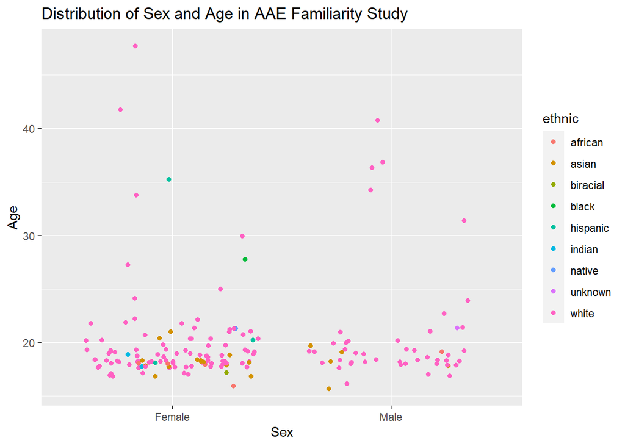

```r
# code chunk for Q10
demographics |>
  ggplot(mapping = aes(x = sex, y = age, color = ethnic)) +
    geom_jitter() +
    labs(
      title = "Distribution of Sex and Age in AAE Familiarity Study",
      x = "Sex",
      y = "Age"
    )
```

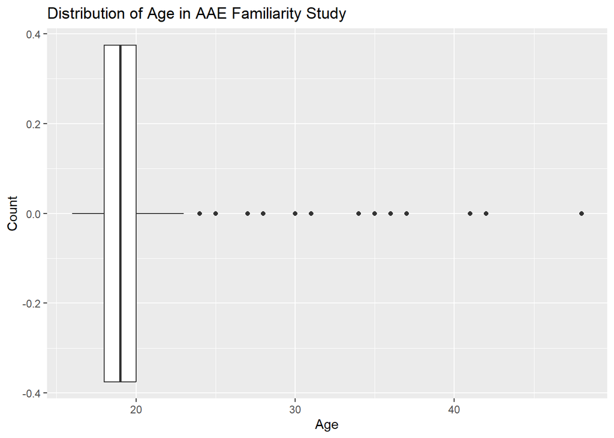

```r
demographics |>
  ggplot(mapping = aes(x = age)) +
    geom_boxplot() +
    labs(
      title = "Distribution of Age in AAE Familiarity Study",
      x = "Age",
      y = "Count"
    )
```

## Familiar words

For each demographic group listed below, determine which word(s) in this study was(were) the most **and** least familiar on average.

**Tip**

Helpful functions: `filter()`, `group_by()`, `summarize()`, `slice_max()`, `slice_min()`

Useful variables: `word`, `familiarity`, `sex`, `age`, `ethnic`

**11. People below the age of 20.**

Most familiar: off the hook

Least familiar: catch the vapors

```r
# code chunk for Q11
under20 <- hiphop_clean |>
  filter(age < 20) |>
  group_by(word) |>
  summarize(
    familiarity = mean(as.numeric(familiarity))
  )
under20 |>
  slice_max(familiarity)
```

```
# A tibble: 1 × 2
  word         familiarity
  <chr>              <dbl>
1 off the hook        4.42
```

```r
under20 |>
  slice_min(familiarity)
```

```
# A tibble: 1 × 2
  word             familiarity
  <chr>                  <dbl>
1 catch the vapors        1.03
```

**12. Non-white women.**

Most familiar: feel me

Least familiar: break someone out, dukey rope, plex, rollie

```r
# code chunk for Q12
nonwhitewomen <- hiphop_clean |>
  filter(white == FALSE & sex == "Female") |>
  group_by(word) |>
  summarize(
    familiarity = mean(as.numeric(familiarity))
  )
nonwhitewomen |>
  slice_max(familiarity)
```

```
# A tibble: 1 × 2
  word    familiarity
  <chr>         <dbl>
1 feel me        4.19
```

```r
nonwhitewomen |>
  slice_min(familiarity)
```

```
# A tibble: 4 × 2
  word              familiarity
  <chr>                   <dbl>
1 break someone out           1
2 dukey rope                  1
3 plex                        1
4 rollie                      1
```

**13. White men above the age of 30.**

Most familiar: 5-0

Least familiar: 25 different words including finna, beezy, crump

```r
# code chunk for Q13
whiteMenOver30 <- hiphop_clean |>
  filter(white == TRUE & sex == "Male" & age > 30) |>
  group_by(word) |>
  summarize(
    familiarity = mean(as.numeric(familiarity))
  )
whiteMenOver30 |>
  slice_max(familiarity)
```

```
# A tibble: 1 × 2
  word  familiarity
  <chr>       <dbl>
1 5-0           4.2
```

```r
whiteMenOver30 |>
  slice_min(familiarity)
```

```
# A tibble: 25 × 2
   word              familiarity
   <chr>                   <dbl>
 1 ay yo trip                  1
 2 beezy                       1
 3 break someone out           1
 4 catch the vapors            1
 5 crossroads                  1
 6 crump                       1
 7 dap                         1
 8 dollar cab                  1
 9 domino                      1
10 duckets                     1
# … with 15 more rows
```

## Study Subjects

A joke among the [Tidy Tuesday](https://www.tidytuesday.com/) community is that Justin Bieber was one of the subjects in this study. Bieber, a white male, from a relatively small town (10,000-60,000 people) in Ontario would have been 17-23 at the time of the study.

**14. Determine which subject you believe is secretly Bieber, justify your answer.**

**Tip**

Refer again to the data set description. There is another clue about Bieber’s identity.

```r
# code chunk for Q14
hiphop_clean |>
  distinct(subj, .keep_all = TRUE) |>
  filter(sex == "Male" &
           between(
             x = city,
             left = 10000,
             right = 60000
             ) &
           between(
             x = age,
             left = 17,
             right = 23
             ) &
           white == TRUE
         ) |>
  slice_max(bieber)
```

```
# A tibble: 1 × 39
  word     subj  sex     age ethnic  city county  intl vocal class…¹  folk  rock
  <chr>    <chr> <fct> <dbl> <fct>  <dbl>  <dbl> <dbl> <dbl>   <dbl> <dbl> <dbl>
1 [to be]… p17   Male     18 white  56377 331582     0     1       0     0     1
# … with 27 more variables: country <dbl>, pop <dbl>, alternative <dbl>,
#   hiphop <dbl>, unclassifiable <dbl>, countyBlack <dbl>, jayz <fct>,
#   barkley <fct>, boondocks <fct>, monique <fct>, bieber <fct>,
#   asianMove <dbl>, blackMove <dbl>, hispanicMove <dbl>, nativeMove <dbl>,
#   SAAMEMove <dbl>, whiteMove <dbl>, blackWeekly <dbl>, jayz1 <fct>,
#   boondocks1 <fct>, familiarity <fct>, trial <dbl>, fam1 <dbl>,
#   popularityScore <fct>, numPreferredArtists <dbl>, …
```

It appears that p17 may be Bieber, as they knew 5 bieber songs along with qualifying with the other demographics

# Lab 3 Submission

You will submit **only** your rendered HTML file. Your HTML file is required to have the following specifications in the YAML options (at the top of your document):

- be self-contained (`self-contained: true`)
- include your source code (`code-tools: true`)
- include all your code and output (`echo: true`)
- include **no** messages from loading in packages or the data (`messages: false`)

**If any of the options are not included, your Lab 3 or Challenge 3 assignment will receive an “Incomplete” and you will be required to submit a revision.**

# Challenge 3: Group Comparisons & Data Ethics

## Published Comparisons

In the published article ([You Know What It Is: Learning Words through Listening to Hip-Hop](https://journals.plos.org/plosone/article/file?id=10.1371/journal.pone.0028248&type=printable)), the author presents a series of comparisons about the variables which most explain an individual’s familiarity with African American English (AAE).

Let us instead compare the number of artists participants reported liking for each genre. Specifically, you will determine which music genre most differentiates each of the demographic groups provided.

> Which genre had much higher average (mean or median) reported artists in one group than the other.
> - Male versus Female
> - White versus Non-White

**Tip**

You might find it helpful to first create a new data set with only the variables you are interested in! Look at the Music Variables in the data set description along with the demographics of interest.

Helpful functions: `select()`, `group_by()`, `summarize()`, `across()`

Other useful operations in R: `mean()`, `diff()`, `abs()`, `which.max()`

## Study Design Critique – Data Ethics

Myself, members of the Tidy Tuesday community, and previous 331 students have voiced concerns regarding the design and social context of this study.

You’ve already read the [data description (link)](http://conservancy.umn.edu/bitstream/handle/11299/116327/5/explanationAAEHiphopChesley.txt) regarding how participants were recruited for participation in this study. **Now**, you need to read additional details regarding aspects of the study in the published paper: [You Know What It Is: Learning Words through Listening to Hip-Hop](https://journals.plos.org/plosone/article/file?id=10.1371/journal.pone.0028248&type=printable).

> Based on the design of this study and its context (African American English), what are **at least two** concerns you have? Keep in mind this critique aligns with conversations regarding data ethics. Thus, your concerns need to address the racial aspects of the design of this study.

# Challenge 3 Submission

Your challenge should be submitted as a **separate file**, **not** at the bottom of your Lab 3 file. Please submit your rendered HTML file. You can copy and paste this code into a **new** Quarto file. Your Challenge 3 submission should only included code necessary for completing the Challenge, nothing else.

You will submit **only** your rendered HTML file. Your HTML file is required to have the following specifications in the YAML options (at the top of your document):

- be self-contained (`self-contained: true`)
- include your source code (`code-tools: true`)
- include all your code and output (`echo: true`)
- include **no** messages from loading in packages or the data (`messages: false`)

**If any of the options are not included, your Lab 3 or Challenge 3 assignment will receive an “Incomplete” and you will be required to submit a revision.**